# IITG Grade Prediction

- A flagship project by **Consulting & Analytics Club of IIT Guwahati** to understand the relation between the grades of a first year student at IIT Guwahati with their previous background and their activities at the campus.
- The project was aimed to help the **next batch of incoming freshers** to better prioritize their activities at campus
- The data was collected via **door-to-door survey collection** in all hostels by representatives of C&A Club evenly to allow for data collection in all hostels.
- An online survey was avoided to have no fake information to be input by the students.
- The anonimity of each survey taker was taken care of.

```python
import numpy as np
import pandas as pd
import seaborn as sns
import matplotlib.pyplot as plt

%matplotlib inline
```

```python
pd.set_option('display.max_columns', None)
data = pd.read_csv('grade_pred_tidy.csv')
```

```python
data.head()
```

|  | Unnamed: 0 | gender | branch | dropper | tenth_board | twelvth_board | coaching | coaching_city | coaching_name | home_state | home_city | fam_size | mom_ed | dad_ed | mom_job | dad_job | study_time | tech_clubs | cult_clubs | fest | hostel | intra_hostel | ed_loan | time_outside | attendance | relationship | tv_time | library | sleep_time | … |
| --- | --- | --- | --- | --- | --- | --- | --- | --- | --- | --- | --- | --- | --- | --- | --- | --- | --- | --- | --- | --- | --- | --- | --- | --- | --- | --- | --- | --- | --- | --- |
| 0 | 1 | Male | BSBE | No | CBSE | CBSE | No | NaN | NaN | Rajasthan | Bikaner | 9 | Post Graduate | Post Graduate | Housewife | Business | Irregular | CnA, Quiz club | Debsoc | Techniche | Umiam | 6-7 | No | 12.0 | Below 90? | Single | 2.0 | During Exams | After 12 am | … |
| 1 | 2 | Male | BSBE | No | CBSE | State | Yes | Indore | Allen | Madhya Pradesh | Maheshwar | 6 | Graduate | Post Graduate | Housewife | Govt | Everyday upto 2-4 hours | CnA, Aero | NaN | NaN | Kapili | 5 to 6 | No | 4.0 | Above 90? | Single | 1.0 | Rarely | After 12 am | … |
| 2 | 3 | Male | CL | No | CBSE | CBSE | Yes | patna | vmc | bihar | sasaram | 4 | 10th Pass | Graduate | Housewife | Business | NaN | CnA | NaN | Techniche | Brahmaputra | 3 | Yes | 2.0 | Below 90? | Single | 1.0 | Rarely | After 12 am | … |
| 3 | 4 | Male | CL | No | CBSE | CBSE | Yes | patna | vmc | bihar | sasaram | 4 | 10th Pass | Graduate | Housewife | Business | NaN | CnA | NaN | Techniche | Brahmaputra | 3 | Yes | 2.0 | Below 90? | Single | 1.0 | Rarely | After 12 am | … |
| 4 | 5 | Male | ME | No | CBSE | CBSE | Yes | Kottayam | T.I.M.E | Maharashtra | Yavatmal | 5 | 10th Pass | 12th Pass | Housewife | Else | Everyday upto 0-2 hours | Robotics | NaN | NaN | Brahmaputra | 1hour | Yes | 3.0 | Above 90? | Single | 1.0 | During Exams | After 10 pm | … |

```python
data.drop('Unnamed: 0', axis=1, inplace=True)
```

```python
data.head()
```

|  | gender | branch | dropper | tenth_board | twelvth_board | coaching | coaching_city | coaching_name | home_state | home_city | fam_size | mom_ed | dad_ed | mom_job | dad_job | study_time | tech_clubs | cult_clubs | fest | hostel | intra_hostel | ed_loan | time_outside | attendance | relationship | tv_time | library | sleep_time | sleep_duration | … |
| --- | --- | --- | --- | --- | --- | --- | --- | --- | --- | --- | --- | --- | --- | --- | --- | --- | --- | --- | --- | --- | --- | --- | --- | --- | --- | --- | --- | --- | --- | --- |
| 0 | Male | BSBE | No | CBSE | CBSE | No | NaN | NaN | Rajasthan | Bikaner | 9 | Post Graduate | Post Graduate | Housewife | Business | Irregular | CnA, Quiz club | Debsoc | Techniche | Umiam | 6-7 | No | 12.0 | Below 90? | Single | 2.0 | During Exams | After 12 am | 7 | … |
| 1 | Male | BSBE | No | CBSE | State | Yes | Indore | Allen | Madhya Pradesh | Maheshwar | 6 | Graduate | Post Graduate | Housewife | Govt | Everyday upto 2-4 hours | CnA, Aero | NaN | NaN | Kapili | 5 to 6 | No | 4.0 | Above 90? | Single | 1.0 | Rarely | After 12 am | 6 | … |
| 2 | Male | CL | No | CBSE | CBSE | Yes | patna | vmc | bihar | sasaram | 4 | 10th Pass | Graduate | Housewife | Business | NaN | CnA | NaN | Techniche | Brahmaputra | 3 | Yes | 2.0 | Below 90? | Single | 1.0 | Rarely | After 12 am | 7 | … |
| 3 | Male | CL | No | CBSE | CBSE | Yes | patna | vmc | bihar | sasaram | 4 | 10th Pass | Graduate | Housewife | Business | NaN | CnA | NaN | Techniche | Brahmaputra | 3 | Yes | 2.0 | Below 90? | Single | 1.0 | Rarely | After 12 am | 7 | … |
| 4 | Male | ME | No | CBSE | CBSE | Yes | Kottayam | T.I.M.E | Maharashtra | Yavatmal | 5 | 10th Pass | 12th Pass | Housewife | Else | Everyday upto 0-2 hours | Robotics | NaN | NaN | Brahmaputra | 1hour | Yes | 3.0 | Above 90? | Single | 1.0 | During Exams | After 10 pm | 7 | … |

```python
data.isnull().sum()
```

```
gender                   0
branch                   0
dropper                  0
tenth_board              0
twelvth_board            0
coaching                 0
coaching_city            5
coaching_name            6
home_state               0
home_city                0
fam_size                 0
mom_ed                   1
dad_ed                   0
mom_job                  0
dad_job                  0
study_time               2
tech_clubs             114
cult_clubs             253
fest                   116
hostel                   0
intra_hostel             0
ed_loan                  0
time_outside             1
attendance               0
relationship             0
tv_time                  0
library                  0
sleep_time               0
sleep_duration           0
sleep_day                0
addiction              359
ta_relation              0
lab                      0
tut                      0
quiz                     0
midsem                   0
endsem                   0
branch_change            0
attention_class          0
study_preference         0
material_preference      0
branch_interest          0
core                     0
cpi                      0
dtype: int64
```

# Univariate Explorations

```python
green1 = [22/256, 111/256, 76/256]
blue1 = [29/256, 82/256, 120/256]
green2 = [0/256, 83/256, 47/256]
blue2 = [38/256, 51/256, 86/256]
green3 = [50/256, 199/256, 127/256]
blue3 = [26/256, 196/256, 219/256]
red1 = [125/256, 25/256, 0/256]
red2 = [178/256, 24/256, 71/256]
```

## Gender

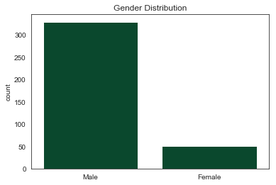

```python
# Gender variable
sns.set_style("white")
sns.countplot(data =data, x='gender', color=green2)
plt.title('Gender Distribution')
plt.xlabel('');
```

**We have a highly imbalanced distribution of Gender in Campus**

[output not shown]

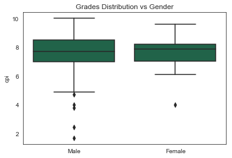

```python
# Gender vs Grade
sns.boxplot(data=data, x='gender', y='cpi', color=green1)
plt.title('Grades Distribution vs Gender')
plt.xlabel('');
```

**The grades of are less variant and more left skewed fro females. Let us try to understand the same again below**

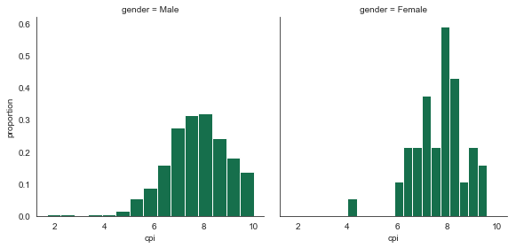

```python
g = sns.FacetGrid(data=data, col='gender', size=4)
g.map(plt.hist, 'cpi', color=green1, density=True, bins=15);
g.set_ylabels('proportion');
```

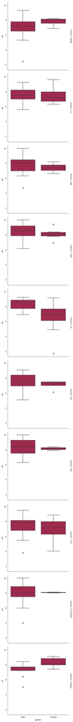

```python
# Gender, Branch and Grade
g = sns.FacetGrid(data=data, row='branch', margin_titles=True, size=5)
g.map(sns.boxplot, 'gender', 'cpi', color=red2);
g.set_titles('Distribution of CPI in Males vs females in all branches');
```

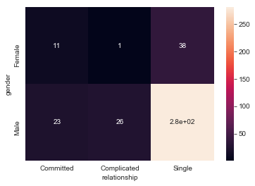

```python
# Gender, Relationship
sns.heatmap(pd.crosstab(data.gender, data.relationship), annot=True);
```

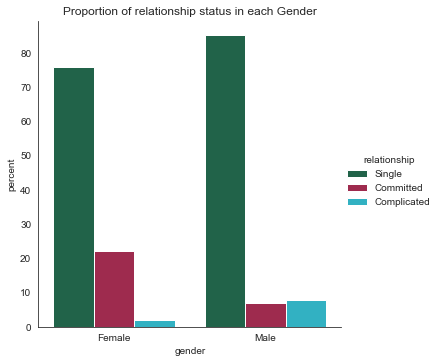

```python
# Better plot for Gender and Relationship
(data
.groupby('gender')['relationship']
.value_counts(normalize=True)
.mul(100)
.rename('percent')
.reset_index()
.pipe((sns.catplot,'data'), x='gender',y='percent',hue='relationship',kind='bar', palette = [green1, red2, blue3]));
plt.title('Proportion of relationship status in each Gender');
```

## Relationship Status

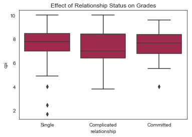

```python
# Relationship Status and Grades
sns.boxplot(data=data, x='relationship', y='cpi', color=red2);
plt.title('Effect of Relationship Status on Grades');
```

## Branch

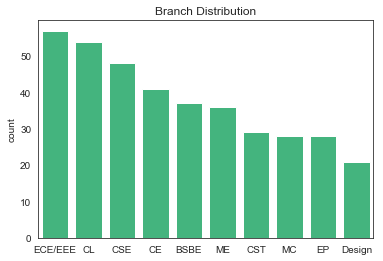

```python
# Branch variable
sns.set_style("white")
sns.countplot(data =data, x='branch', color=green3, order = data.branch.value_counts().index);
plt.title('Branch Distribution');
plt.xlabel('');
```

**The distribution almost resembles the batch size of each branch**

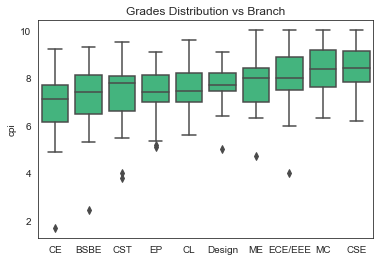

```python
# Branch vs Grade
sns.boxplot(data=data, x='branch', y='cpi', color=green3, order=data.groupby('branch')['cpi'].mean().sort_values().index)
plt.title('Grades Distribution vs Branch')
plt.xlabel('');
```

**The division of grades is almost similar for top 4 branches**

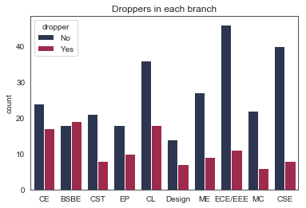

```python
# Is there any relation between branch and number of droppers
sns.countplot(data=data, x='branch', hue='dropper',
             palette=[blue2, red2], order=data.groupby('branch')['cpi'].mean().sort_values().index)
plt.title('Droppers in each branch')
plt.xlabel('');
```

**A better plot would be just the ratio of droppers in each branch. A definite trend is being seen in the same though**

```python
pd.crosstab(data.branch, data.dropper, margins=True)
```

| dropper branch | No | Yes | All |
| --- | --- | --- | --- |
| BSBE | 18 | 19 | 37 |
| CE | 24 | 17 | 41 |
| CL | 36 | 18 | 54 |
| CSE | 40 | 8 | 48 |
| CST | 21 | 8 | 29 |
| Design | 14 | 7 | 21 |
| ECE/EEE | 46 | 11 | 57 |
| EP | 18 | 10 | 28 |
| MC | 22 | 6 | 28 |
| ME | 27 | 9 | 36 |
| All | 266 | 113 | 379 |

```python
branch_dropper = pd.crosstab(data.branch, data.dropper, margins=True).iloc[:-1]
branch_dropper['dropper_ratio'] = branch_dropper['Yes']/branch_dropper['All']
branch_dropper
```

| dropper branch | No | Yes | All | dropper_ratio |
| --- | --- | --- | --- | --- |
| BSBE | 18 | 19 | 37 | 0.513514 |
| CE | 24 | 17 | 41 | 0.414634 |
| CL | 36 | 18 | 54 | 0.333333 |
| CSE | 40 | 8 | 48 | 0.166667 |
| CST | 21 | 8 | 29 | 0.275862 |
| Design | 14 | 7 | 21 | 0.333333 |
| ECE/EEE | 46 | 11 | 57 | 0.192982 |
| EP | 18 | 10 | 28 | 0.357143 |
| MC | 22 | 6 | 28 | 0.214286 |
| ME | 27 | 9 | 36 | 0.250000 |

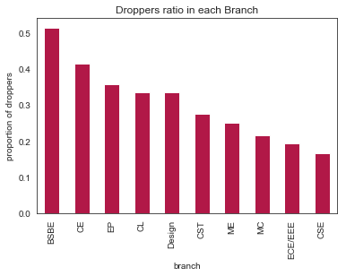

```python
branch_dropper.sort_values('dropper_ratio', ascending=False)['dropper_ratio'].plot.bar(color=red2)
plt.title('Droppers ratio in each Branch')
plt.ylabel('proportion of droppers');
```

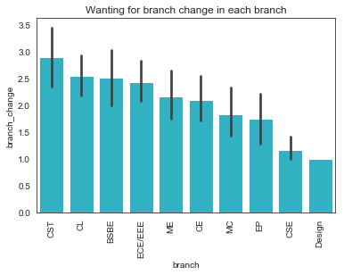

```python
# Branch and Branch change
sns.barplot(data=data, x='branch', y='branch_change', order=data.groupby('branch')['branch_change'].mean().sort_values(ascending=False).index,color=blue3);
plt.title('Wanting for branch change in each branch');
plt.xticks(rotation=90);
```

**Basically, the higher JEE ranks brances have more droppers**

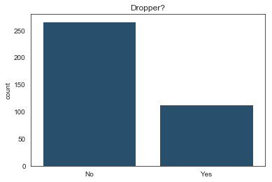

```python
# Dropper variable
sns.set_style("white")
sns.countplot(data =data, x='dropper', color=blue1);
plt.title('Dropper?');
plt.xlabel('');
```

## Coaching

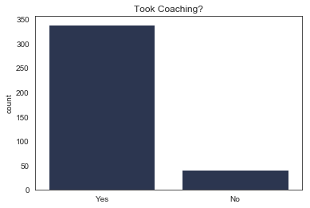

```python
# Coaching variable
sns.set_style("white")
sns.countplot(data =data, x='coaching', color=blue2, order = data.coaching.value_counts().index);
plt.title('Took Coaching?');
plt.xlabel('');
```

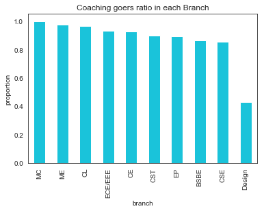

```python
# Coaching and Branch
branch_coaching = pd.crosstab(data.branch, data.coaching, margins=True).iloc[:-1]
branch_coaching['coaching_ratio'] = branch_coaching['Yes']/branch_coaching['All']
branch_coaching.sort_values('coaching_ratio', ascending=False)['coaching_ratio'].plot.bar(color=blue3)
plt.title('Coaching goers ratio in each Branch')
plt.ylabel('proportion');
```

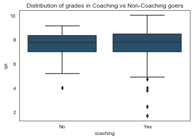

```python
# Coaching and Grades
sns.boxplot(data=data, x='coaching', y='cpi', color=blue1);
plt.title('Distribution of grades in Coaching vs Non-Coaching goers');
```

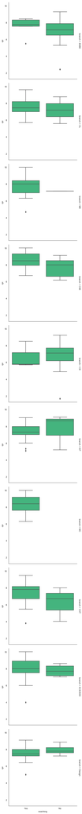

```python
# Coaching, Branch and Grade
g = sns.FacetGrid(data=data, row='branch', margin_titles=True, size=5)
g.map(sns.boxplot, 'coaching', 'cpi', color=green3);
g.set_titles('Distribution of CPI in Coaching vs Non-Coaching in all branches');
```

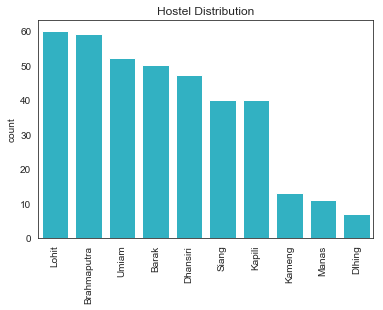

```python
# Hostel variable
sns.set_style("white")
sns.countplot(data =data, x='hostel', color=blue3, order=data.hostel.value_counts().index);
plt.title('Hostel Distribution');
plt.xlabel('');
plt.xticks(rotation=90);
```

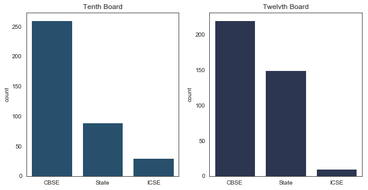

```python
fig = plt.figure(figsize=[10, 5])

ax = fig.add_subplot(1, 2, 1)
# Gender variable
sns.set_style("white")
sns.countplot(data =data, x='tenth_board', color=blue1, ax=ax, order=data.tenth_board.value_counts().index)
plt.title('Tenth Board')
plt.xlabel('')

ax = fig.add_subplot(1, 2, 2)
# Gender variable
sns.set_style("white")
sns.countplot(data =data, x='twelvth_board', color=blue2, order=data.twelvth_board.value_counts().index)
plt.title('Twelvth Board')
plt.xlabel('');
```

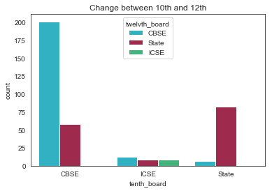

```python
sns.countplot(data=data, x='tenth_board', hue='twelvth_board', palette =[blue3, red2, green3])
plt.title('Change between 10th and 12th');
```

- **Only ICSE students in 10th Board opt for ICSE in 12th Board**
- **Generally, students opt for same board which they opted before**

# Numeric Features

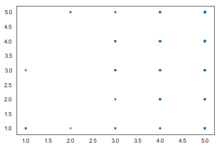

```python
plt.scatter(data = data, x = 'endsem', y = 'lab', s = 'cpi', alpha=2/3);
```

## Hostel

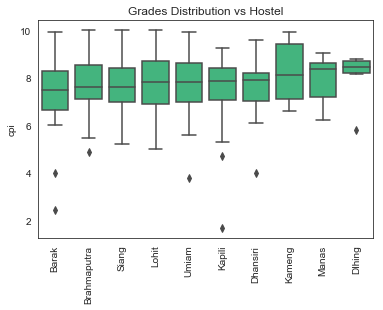

```python
# Hostel vs Grade
sns.boxplot(data=data, x='hostel', y='cpi', color=green3, order=data.groupby('hostel')['cpi'].median().sort_values().index)
plt.title('Grades Distribution vs Hostel')
plt.xlabel('');
plt.xticks(rotation=90);
```

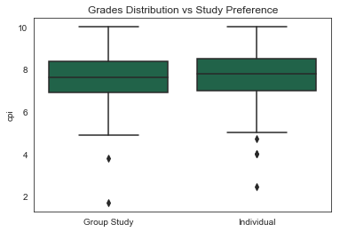

```python
# Study Preference vs Grade
sns.boxplot(data=data, x='study_preference', y='cpi', color=green1, order=data.groupby('study_preference')['cpi'].mean().sort_values().index)
plt.title('Grades Distribution vs Study Preference')
plt.xlabel('');
```

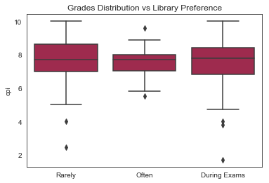

```python
# Study Preference vs Grade
sns.boxplot(data=data, x='library', y='cpi', color=red2, order=data.groupby('library')['cpi'].median().sort_values().index)
plt.title('Grades Distribution vs Library Preference')
plt.xlabel('');
```

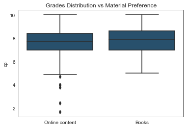

```python
# Material Preference vs Grade
sns.boxplot(data=data, x='material_preference', y='cpi', color=blue1, order=data.groupby('material_preference')['cpi'].mean().sort_values().index)
plt.title('Grades Distribution vs Material Preference')
plt.xlabel('');
```

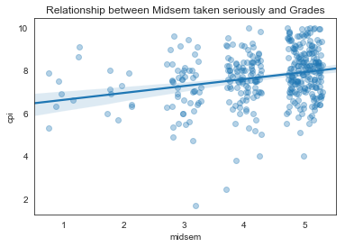

```python
sns.regplot(data=data, x='midsem', y='cpi', x_jitter=0.3, scatter_kws = {'alpha' : 1/3});
plt.title('Relationship between Midsem taken seriously and Grades');
```

[figure not shown]

```python
plt.figure(figsize=[10,10])
sns.heatmap(data[['ta_relation','lab','tut','quiz','midsem','endsem','branch_change','attention_class', 'tv_time', 'time_outside', 'sleep_duration','cpi']].corr(), annot=True);
```

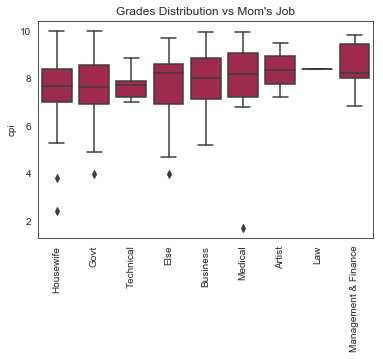

```python
# Material Preference vs Grade
sns.boxplot(data=data, x='mom_job', y='cpi', color=red2, order=data.groupby('mom_job')['cpi'].mean().sort_values().index)
plt.title('Grades Distribution vs Mom\'s Job')
plt.xlabel('');
plt.xticks(rotation=90)
```

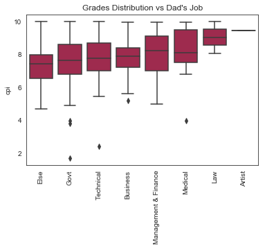

```python
# Material Preference vs Grade
sns.boxplot(data=data, x='dad_job', y='cpi', color=red2, order=data.groupby('dad_job')['cpi'].mean().sort_values().index)
plt.title('Grades Distribution vs Dad\'s Job')
plt.xlabel('');
plt.xticks(rotation=90)
```